# Obesity Among Adults in Mexico from the WHO

Anna Buzzard

22 May, 2020

# Packages and Data

```r
library(tidyverse)
```

```r
obm <- read.csv("obesity_mexico.csv")
str(obm)
head(obm)
summary(obm)
```

I downloaded the “clean data” from the website “Kaggle”, which was first received from the World Health Organization (WHO). The data set from WHO included data of obesity in all other countries, but my focus is on obesity in Mexico.

The data collected is both sexes and of those who are 18+ years in age. The method of measurements is height and weight of participants.

The World Health Organization categorizes obesity for adults as a body mass index of 30 kilograms/meters^2 or more. BMI is a way to measure population-level overweight and obestiy. It is the same for all sexes and ages of adults. BMI, however, may not be an accurate representation of one’s fat (i.e. one could weigh a lot in muscle mass rather than fat).

The purpose of this graph is to show the change in obesity from 1975 to 2016 in both men and women in Mexico. From 1975-2016, there was over a 10% increase in obesity in males, while there was over a 15% increase in obesity in females. Through this chart, we see that this was a gradual change that occured over the course of time, which could be because of a variety of reasons.

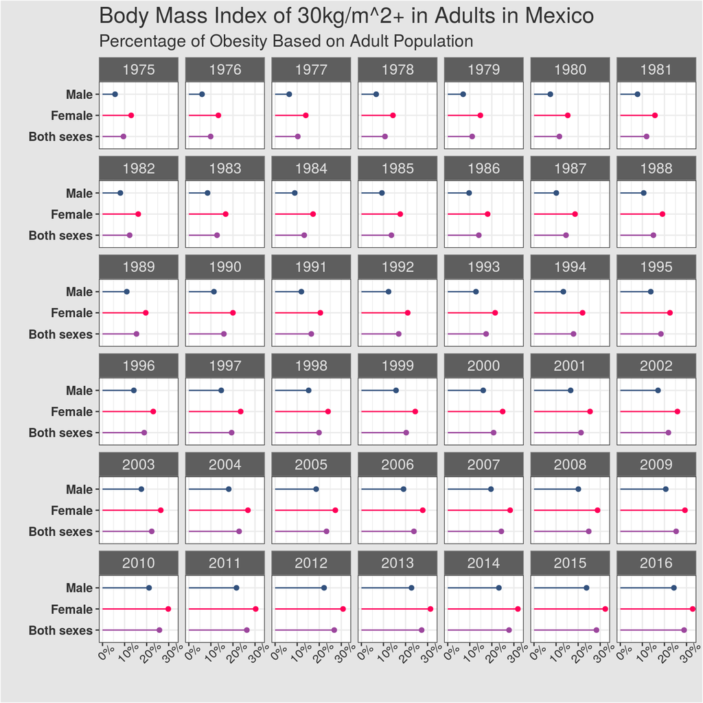

```r
a <- ggplot(data=obm, mapping=aes(
  x=Gender, y=Obesity, color=Gender, fill=Gender)) +
  geom_point() +
  geom_segment(mapping=aes(
    x=Gender, y=Obesity, xend=Gender, yend=0)) +
  scale_x_discrete(name="") +
  scale_y_continuous(name="",
                     labels=paste0(seq(0,30,10),"%")) +
  scale_color_manual(values=c("#9C469D","#FF0058","#32517D")) +
  scale_fill_manual(values=c("#9C469D","#FF0058","#32517D")) +
  labs(title="Body Mass Index of 30kg/m^2+ in Adults in Mexico",
       subtitle="Percentage of Obesity Based on Adult Population ") +
  theme_bw() + facet_wrap(vars(Year)) + coord_flip() +
  theme(legend.position="none",
        axis.title=element_text(size=16,color="#131313"),
        strip.background=element_rect(fill="#5E5E5E",
                                      color="gray50"),
        strip.text=element_text(color="#E2E2E2",size=12),
        axis.text.y=element_text(
          color="#303030",size=10,face="bold"),
        axis.text.x=element_text(
          color="#303030",size=10,angle=45),
        plot.background=element_rect(fill="gray90"),
        plot.title=element_text(size=18,color="#303030"),
        plot.subtitle=element_text(size=14,color="#303030"))

a
```